# Should we use Multi-Cancer Early Detection Testing in Canada?

Author

John Hutchinson - Thesis Project

# Cancer Type Specific Scenarios

- Main results: Lung and Colorectal cancer seem to benefit from MCED (at high participation), however, it is far less effective with breast cancer
- MCED does not work well until it surpasses ~60% participation
- Overall interpretation: MCED is best suited to cancer types with insufficient screening, or when the tests have worse sensitivity/sensitivity. Lung cancer shows that underscreened types benefit, but well-screened types like breast will see a worsening of outcomes. ## Efficiency Frontier

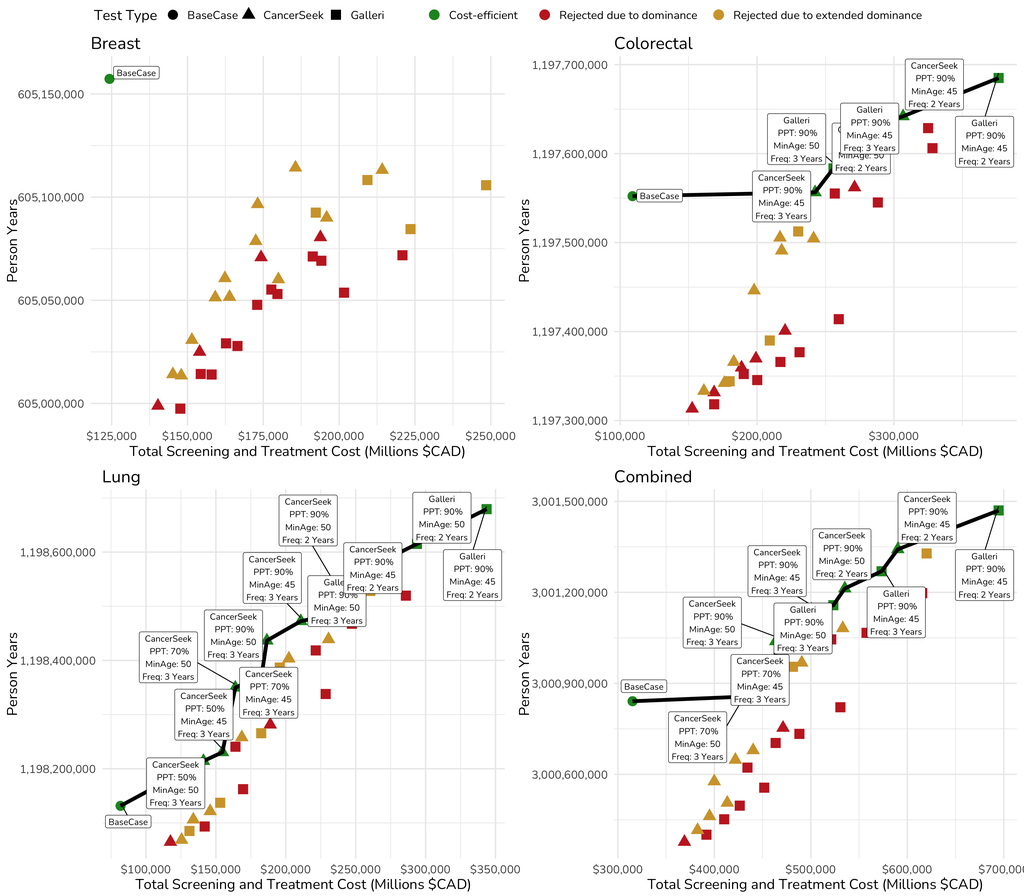

- Breast does not seem to benefit from MCED at all
- Otherwise, several scenarios lead to cost efficiency when person years are the main metric examined

## Breast

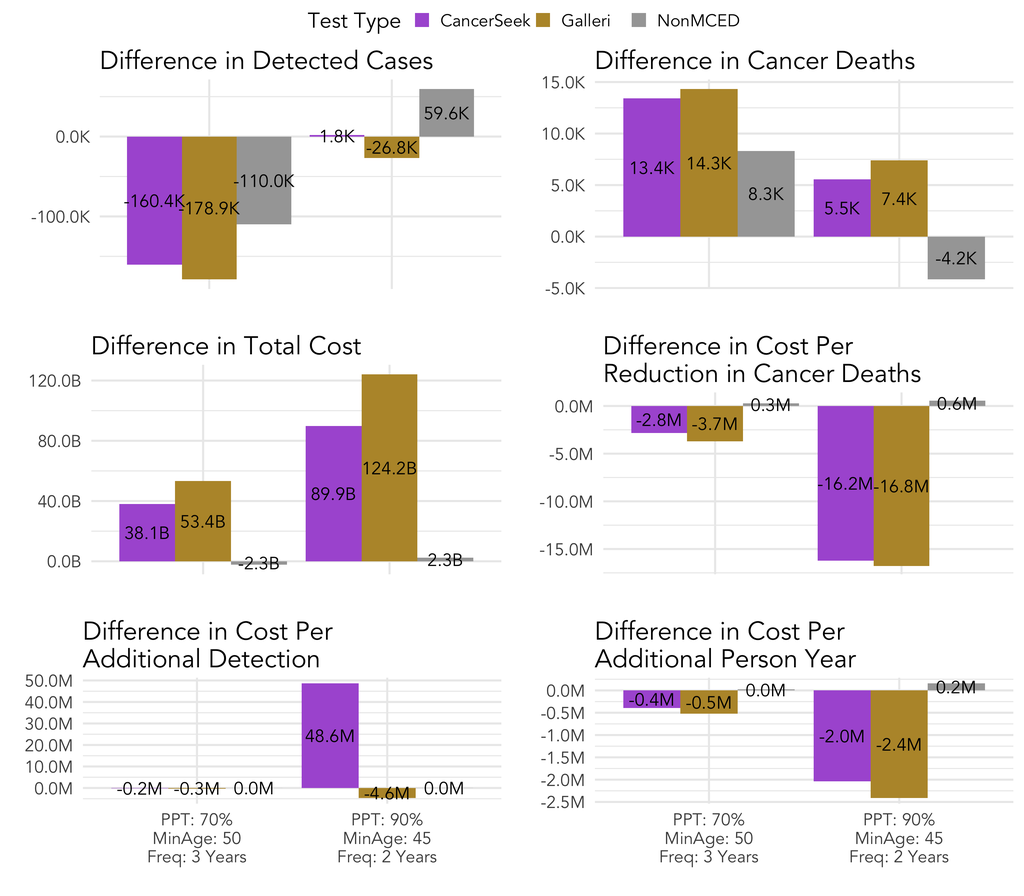

- The selected MCED scenarios generally lead to worse performance (fewer detected cases, more deaths, more cost)
- Overall: MCED never works well for breast

## Colorectal

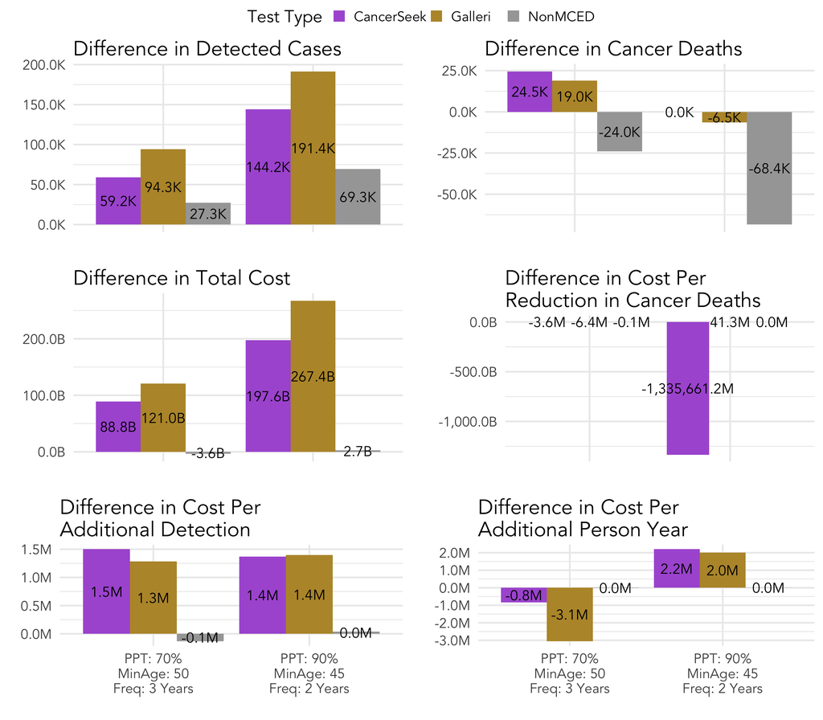

- Galleri with 90% participation is the only MCED scenario that results in fewer cancer deaths.
- It appears in terms of sensitivity, Galleri is better than FIT, and CancerSEEK is worse.
- Overall: MCED only works well for colorectal if it is Galleri and high participation

## Lung

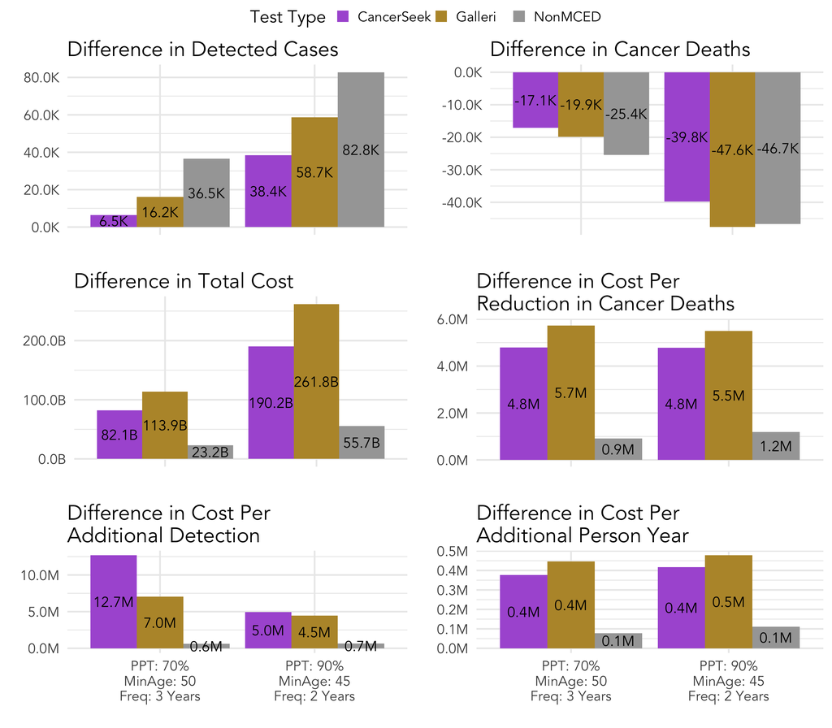

- Beside the NonMCED scenarios, 90% Galleri leads to the lowest increase in cost per additional detection. However, CancerSeek leads to the lowest increase in cost per death averted.
- Overall: MCED always helps with lung (largely due to lack of existing screening)

## Combined

- Beside the NonMCED scenario, CancerSeek 90% leads to the lowest increase in cost per additional detection (among scenarios that increase detections)

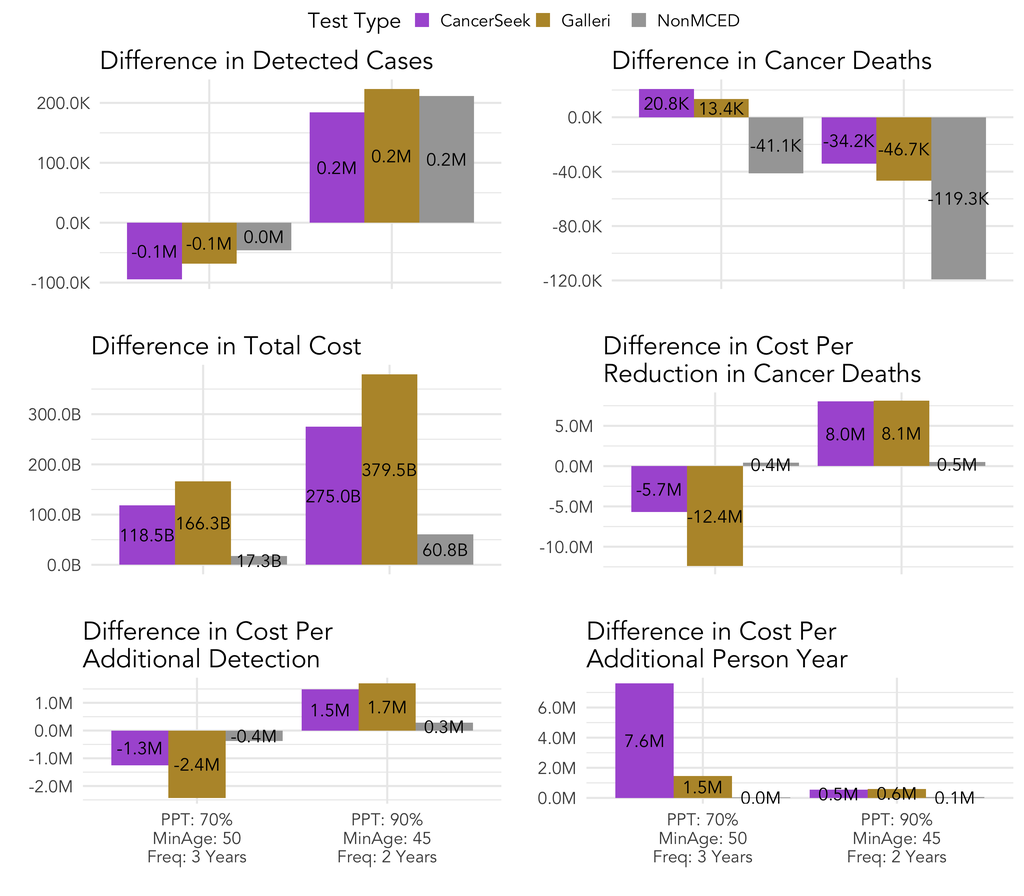

## Linear Modelling

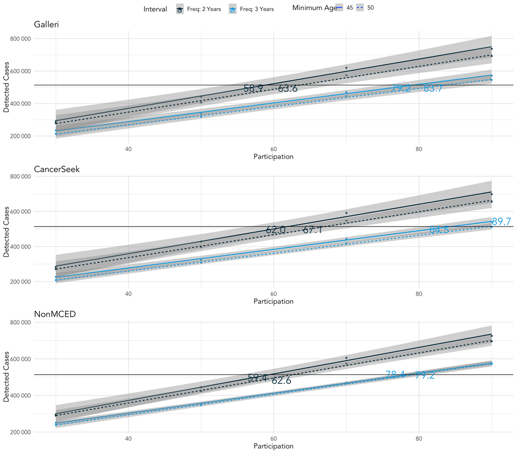